# R Data Analysis

### 5/17/18

## Intro

By the time a country is well developed, its growth in population can change dramatically. What features have strong relations with population growth? How would I go about testing that?

```
## # A tibble: 2,909 x 29
##    `Country Name` `Country Code` `Series Name`               `Series Code`
##    <chr>          <chr>          <chr>                       <chr>
##  1 Afghanistan    AFG            Access to electricity (% o~ EG.ELC.ACCS.~
##  2 Afghanistan    AFG            Individuals using the Inte~ IT.NET.USER.~
##  3 Afghanistan    AFG            People using at least basi~ SH.H2O.BASW.~
##  4 Afghanistan    AFG            Population ages 0-14, total SP.POP.0014.~
##  5 Afghanistan    AFG            Population ages 15-64, tot~ SP.POP.1564.~
##  6 Afghanistan    AFG            Population, total           SP.POP.TOTL
##  7 Afghanistan    AFG            Population growth (annual ~ SP.POP.GROW
##  8 Afghanistan    AFG            Population density (people~ EN.POP.DNST
##  9 Afghanistan    AFG            Children in employment, wo~ SL.TLF.0714.~
## 10 Afghanistan    AFG            Adjusted net national inco~ NY.ADJ.NNTY.~
## # ... with 2,899 more rows, and 25 more variables: `1993 [YR1993]` <chr>,
## #   `1994 [YR1994]` <chr>, `1995 [YR1995]` <chr>, `1996 [YR1996]` <chr>,
## #   `1997 [YR1997]` <chr>, `1998 [YR1998]` <chr>, `1999 [YR1999]` <chr>,
## #   `2000 [YR2000]` <chr>, `2001 [YR2001]` <chr>, `2002 [YR2002]` <chr>,
## #   `2003 [YR2003]` <chr>, `2004 [YR2004]` <chr>, `2005 [YR2005]` <chr>,
## #   `2006 [YR2006]` <chr>, `2007 [YR2007]` <chr>, `2008 [YR2008]` <chr>,
## #   `2009 [YR2009]` <chr>, `2010 [YR2010]` <chr>, `2011 [YR2011]` <chr>,
## #   `2012 [YR2012]` <chr>, `2013 [YR2013]` <chr>, `2014 [YR2014]` <chr>,
## #   `2015 [YR2015]` <chr>, `2016 [YR2016]` <chr>, `2017 [YR2017]` <chr>
```

## Tidying

I now need to clean this data. There a few things I need to do. First, I should rename the Series code column to be reader friendly, then make the dataset tidy. This means that the data should have the following:  
1. Each attribute(Ex, year) forms a column  
2. Each entity(observation) forms a row  
3. Each type of entity forms a table. This means that there rent multiple tables of different entities joined for no reason.  
With our current dataset, multiple years are spanned across columns, and different types of information such as income and percentages are stored in the same column. Tidying data is useful to do before data cleaning. The dplyr library is used for dataset manipulation.

```r
library(dplyr)
#this part is just for renaming purposes, specifically columns with spaces
renamedPopulation <- populationData %>%
  rename(Code = `Series Code`, Country = `Country Code`, CountryName = `Country Name`) %>%
  select(-`Series Name`, -`2017 [YR2017]`) %>%
  filter(CountryName == "United States"| CountryName == "China"| CountryName == "India" | CountryName == "Nigeria" | CountryName == "Japan" | CountryName == "United Kingdom" | CountryName == "Russian Federation")

#now I create a table for each different entity type (code) in this case
electricAccess <- renamedPopulation %>%
  filter(Code == "EG.ELC.ACCS.ZS") %>%
  select(-Code)

internetAccess <- renamedPopulation %>%
  filter(Code == "IT.NET.USER.ZS") %>%
  select(-Code)

waterAccess <- renamedPopulation %>%
  filter(Code == "SH.H2O.BASW.ZS") %>%
  select(-Code)

populationOld <- renamedPopulation %>%
  filter(Code == "SP.POP.1564.TO") %>%
  select(-Code)

populationYoung <- renamedPopulation %>%
  filter(Code == "SP.POP.0014.TO") %>%
  select(-Code)

populationTotal <- renamedPopulation %>%
  filter(Code == "SP.POP.TOTL") %>%
  select(-Code)

populationGrowth <- renamedPopulation %>%
  filter(Code == "SP.POP.GROW") %>%
  select(-Code)

nationalIncome <- renamedPopulation %>%
  filter(Code == "NY.ADJ.NNTY.CD") %>%
  select(-Code)


nationalIncome
```

```
## # A tibble: 7 x 26
##   CountryName     Country `1993 [YR1993]`  `1994 [YR1994]` `1995 [YR1995]`
##   <chr>           <chr>   <chr>            <chr>           <chr>
## 1 China           CHN     387536869441.205 516751956719.8~ 660968081288.1~
## 2 India           IND     240182678179.84  282489402554.91 309913830122.3~
## 3 Japan           JPN     3538627989994.46 3871546107816.~ 4328514624551.~
## 4 Nigeria         NGA     7043400778.33635 9894017752.248~ 18979545439.03~
## 5 Russian Federa~ RUS     224535397025.362 197970042203.1~ 191485536483.8~
## 6 United Kingdom  GBR     915282745680.03  1006306201981.~ 1098272152097.~
## 7 United States   USA     5710970251154.19 6101977128319.~ 6443692303897.~
## # ... with 21 more variables: `1996 [YR1996]` <chr>, `1997
## #   [YR1997]` <chr>, `1998 [YR1998]` <chr>, `1999 [YR1999]` <chr>, `2000
## #   [YR2000]` <chr>, `2001 [YR2001]` <chr>, `2002 [YR2002]` <chr>, `2003
## #   [YR2003]` <chr>, `2004 [YR2004]` <chr>, `2005 [YR2005]` <chr>, `2006
## #   [YR2006]` <chr>, `2007 [YR2007]` <chr>, `2008 [YR2008]` <chr>, `2009
## #   [YR2009]` <chr>, `2010 [YR2010]` <chr>, `2011 [YR2011]` <chr>, `2012
## #   [YR2012]` <chr>, `2013 [YR2013]` <chr>, `2014 [YR2014]` <chr>, `2015
## #   [YR2015]` <chr>, `2016 [YR2016]` <chr>
```

The tables are almost tidy, but this table can still be split up into different tables.

```r
library(tidyr)
#Running this section more than once will break the tables unless you run from the beginning
electricAccess <- electricAccess %>% gather(Year, ElectricityAccessPercentage, -CountryName, -Country)%>%
  mutate("Year" = as.integer(substring(Year, 1, 4))) %>%
  mutate("ElectricityAccessPercentage" = as.double(ElectricityAccessPercentage))

internetAccess <-internetAccess %>% gather(Year, InternetAccessPercentage, -CountryName, -Country)%>%
  mutate("Year" = as.integer(substring(Year, 1, 4))) %>%
  mutate("InternetAccessPercentage" = as.double(InternetAccessPercentage))

waterAccess<- waterAccess %>% gather(Year, WaterAccessPercentage, -CountryName, -Country)%>%
  mutate("Year" = as.integer(substring(Year, 1, 4))) %>%
  mutate("WaterAccessPercentage" = as.double(WaterAccessPercentage))

populationTotal <- populationTotal %>% gather(Year, TotalPopulation, -CountryName, -Country)%>%
  mutate("Year" = as.integer(substring(Year, 1, 4))) %>%
  mutate("TotalPopulation" = as.integer(TotalPopulation))

populationGrowth <- populationGrowth %>% gather(Year, PopulationGrowthPercentage, -CountryName, -Country)%>%
  mutate("Year" = as.integer(substring(Year, 1, 4))) %>%
  mutate("PopulationGrowthPercentage" = as.double(PopulationGrowthPercentage))

nationalIncome <- nationalIncome %>% gather(Year, Income, -CountryName, -Country)%>%
  mutate("Year" = as.integer(substring(Year, 1, 4))) %>%
  mutate("Income" = as.double(Income))

nationalIncome
```

```
## # A tibble: 168 x 4
##    CountryName        Country  Year        Income
##    <chr>              <chr>   <int>         <dbl>
##  1 China              CHN      1993  387536869441
##  2 India              IND      1993  240182678180
##  3 Japan              JPN      1993 3538627989994
##  4 Nigeria            NGA      1993    7043400778
##  5 Russian Federation RUS      1993  224535397025
##  6 United Kingdom     GBR      1993  915282745680
##  7 United States      USA      1993 5710970251154
##  8 China              CHN      1994  516751956720
##  9 India              IND      1994  282489402555
## 10 Japan              JPN      1994 3871546107816
## # ... with 158 more rows
```

Now that our data is tidy, we can start to look at our data. We do this to check if there is anything off with our data such as skews and outliers.

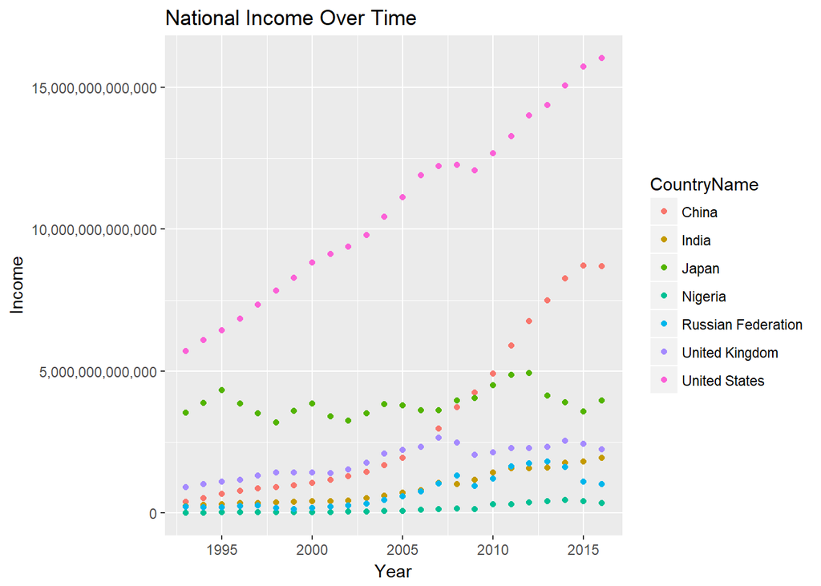

```r
library(ggplot2)
tplot <-  nationalIncome %>%
  ggplot(aes(x=Year, y=Income)) +
  labs(title="National Income Over Time",
       x = "Year",
       y = "Income") +
  geom_point(aes(color = CountryName)) +
  scale_x_continuous(breaks=scales::pretty_breaks(n = 5)) +
  scale_y_continuous(labels = scales::comma)
tplot
```

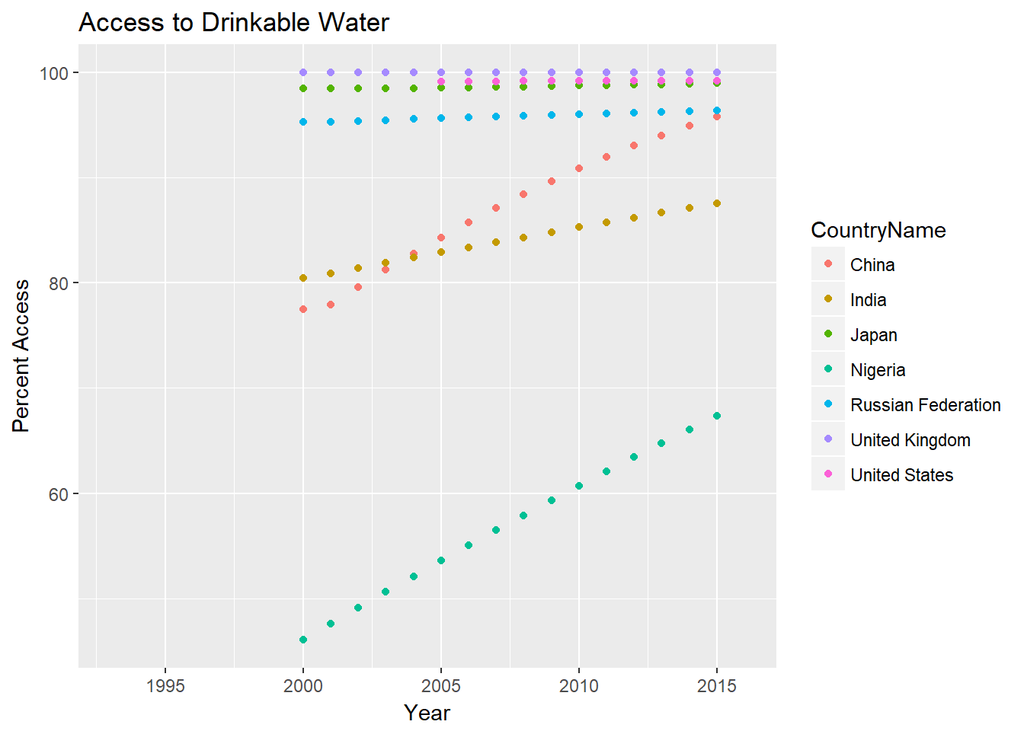

```r
library(ggplot2)
tplot <-  waterAccess %>%
  ggplot(aes(x=Year, y=WaterAccessPercentage)) +
  labs(title="Access to Drinkable Water",
       x = "Year",
       y = "Percent Access") +
  geom_point(aes(color = CountryName)) +
  scale_x_continuous(breaks=scales::pretty_breaks(n = 5))
tplot
```

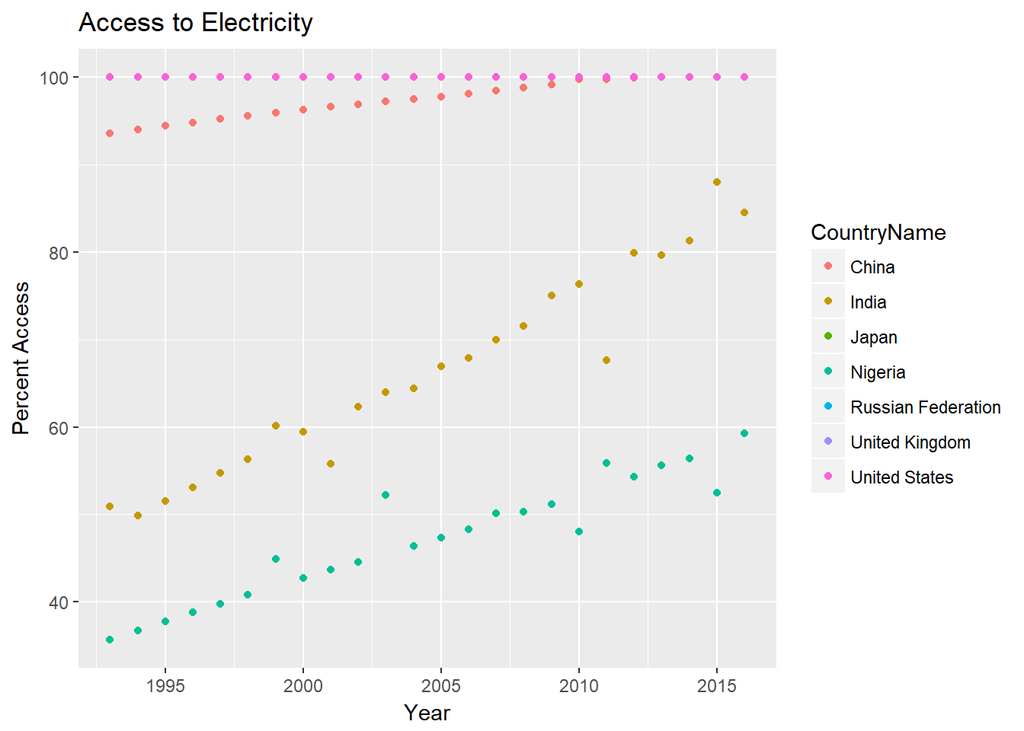

```r
library(ggplot2)
tplot <-  electricAccess %>%
  ggplot(aes(x=Year, y=ElectricityAccessPercentage)) +
  labs(title="Access to Electricity",
       x = "Year",
       y = "Percent Access") +
  geom_point(aes(color = CountryName)) +
  scale_x_continuous(breaks=scales::pretty_breaks(n = 5))
tplot
```

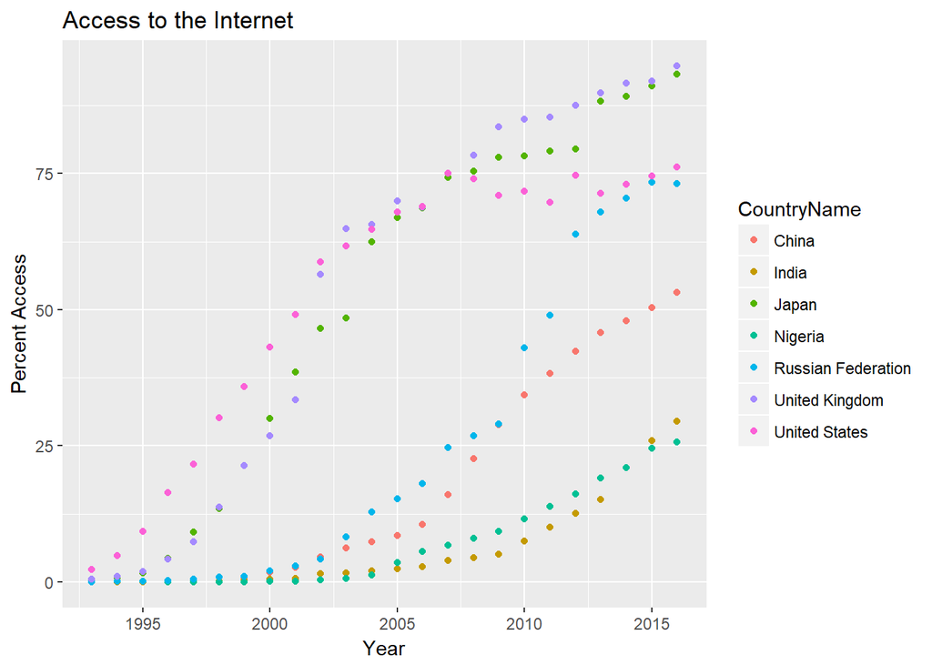

```r
tplot <-  internetAccess %>%
  ggplot(aes(x=Year, y=InternetAccessPercentage)) +
  labs(title="Access to the Internet",
       x = "Year",
       y = "Percent Access") +
  geom_point(aes(color = CountryName)) +
  scale_x_continuous(breaks=scales::pretty_breaks(n = 5))
tplot
```

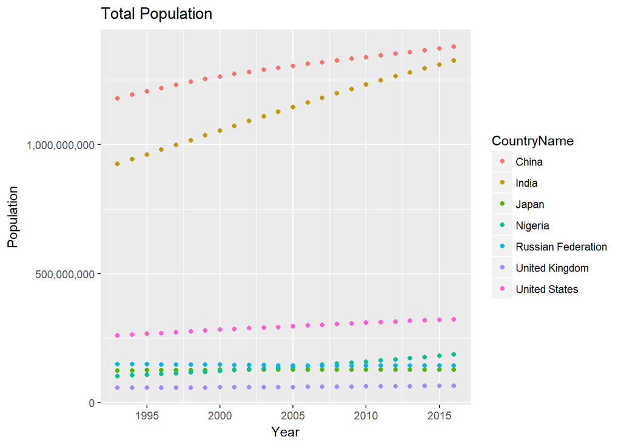

```r
library(ggplot2)
tplot <-  populationTotal %>%
  ggplot(aes(x=Year, y=TotalPopulation)) +
  labs(title="Total Population",
       x = "Year",
       y = "Population") +
  geom_point(aes(color = CountryName)) +
  scale_x_continuous(breaks=scales::pretty_breaks(n = 5)) +
  scale_y_continuous(labels = scales::comma)
tplot
```

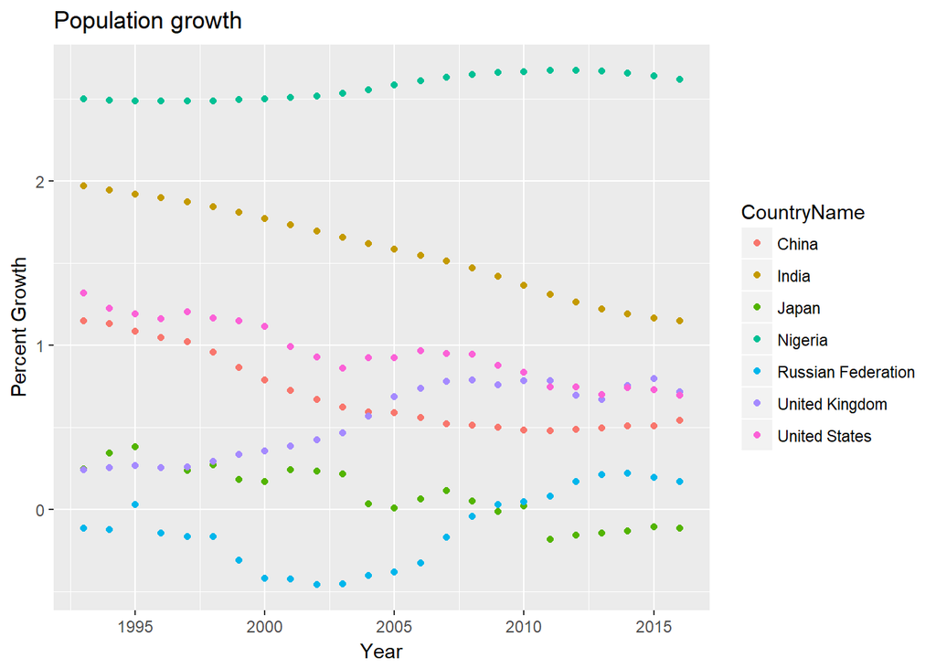

```r
tplot <-  populationGrowth %>%
  ggplot(aes(x=Year, y=PopulationGrowthPercentage)) +
  labs(title="Population growth",
       x = "Year",
       y = "Percent Growth") +
  geom_point(aes(color = CountryName)) +
  scale_x_continuous(breaks=scales::pretty_breaks(n = 5))
tplot
```

There is some important information we can see from these general charts. We can see that it looks like having a high access to electricity possibly follows lower population growth. However, the electricity data is missing some values, specifically data from Russia, Japan, and The United Kingdom. This data is missing systematically, as it looks like no measurements were taken at all in those countries. Because so much is missing, this dataset will be avoided.

The drinkable water dataset doesn’t start until 2000, and within that, the US doesn’t start recording until 2005. Looking at the data, it does seem linear, so I will estimate the unknown values with a linear model. Because water levels across different countries do not seem to have any relation with each other, I will use linear regression with water access regressed on Year for each country.

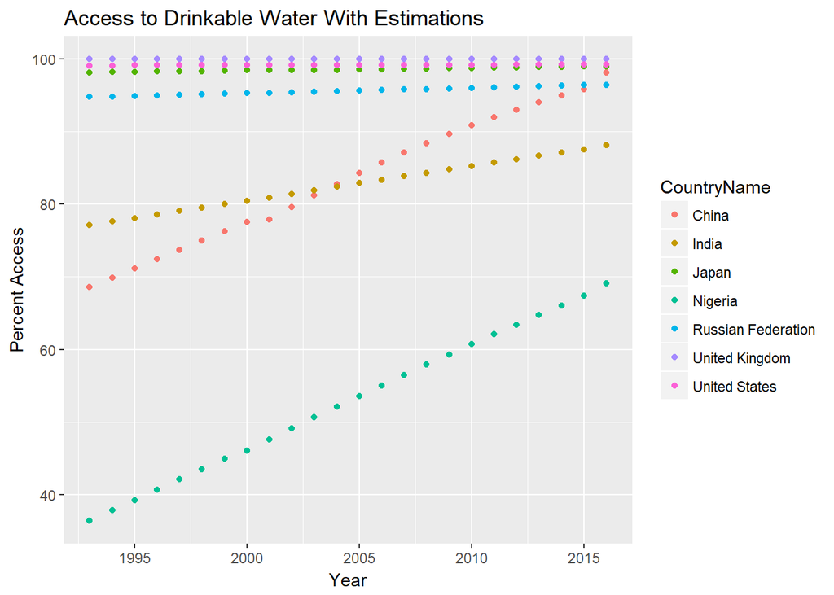

```r
#function used to predict the empty values
estimateWaterValues <- function(cName, waterDF){

  waterPredictor <- waterDF %>%
    filter(CountryName == cName) %>%
    lm(WaterAccessPercentage~Year, data = .)

  waterDF <- waterDF %>%
    modelr::add_predictions(waterPredictor, var="tempPrediction")

  waterDF <- waterDF %>%
    mutate("WaterAccessPercentage" = ifelse(!is.na(WaterAccessPercentage), WaterAccessPercentage, ifelse(CountryName == cName ,  tempPrediction, NA) )) %>%
    select(-tempPrediction)

  return(waterDF)
}
waterAccess <- estimateWaterValues("United States", waterAccess)
waterAccess <- estimateWaterValues("China", waterAccess)
waterAccess <- estimateWaterValues("Japan", waterAccess)
waterAccess <- estimateWaterValues("India", waterAccess)
waterAccess <- estimateWaterValues("Nigeria", waterAccess)
waterAccess <- estimateWaterValues("Russian Federation", waterAccess)
waterAccess <- estimateWaterValues("United Kingdom", waterAccess)

library(ggplot2)
tplot <-  waterAccess %>%
  ggplot(aes(x=Year, y=WaterAccessPercentage)) +
  labs(title="Access to Drinkable Water With Estimations",
       x = "Year",
       y = "Percent Access") +
  geom_point(aes(color = CountryName)) +
  scale_x_continuous(breaks=scales::pretty_breaks(n = 5))
tplot
```

Access to the internet has some null values, but unlike the electricity access, all of the countries were included. However, it looks like the only time data is missing is when the percent of internet access was also very low. In this case, I will set unknowns to 0.

```r
internetAccess <- internetAccess %>%
  mutate("InternetAccessPercentage" = ifelse(is.na(InternetAccessPercentage), 0, InternetAccessPercentage))
```

The china and India total population seem to be outliers. However, their population growth rate can be seen declining.

# EDA

After this visual analysis, I can now check for relationships between what we are testing, population growth and the other data. The parameters I can test are: -Year  
-Population Growth  
-Access to Water  
-Access to the Internet  
-Total Population

Because the tidy tables from earlier were all based on year and country, I was able to join them all seamlessly.

```r
combinedTidyDF = nationalIncome %>%
  inner_join(populationTotal)  %>%
  inner_join(populationGrowth)   %>%
  inner_join(waterAccess)  %>%
  inner_join(internetAccess)
combinedTidyDF
```

```
## # A tibble: 168 x 8
##    CountryName   Country  Year   Income TotalPopulation PopulationGrowthP~
##    <chr>         <chr>   <int>    <dbl>           <int>              <dbl>
##  1 China         CHN      1993  3.88e11      1178440000              1.15
##  2 India         IND      1993  2.40e11       924057817              1.97
##  3 Japan         JPN      1993  3.54e12       124536000              0.247
##  4 Nigeria       NGA      1993  7.04e 9       102761737              2.50
##  5 Russian Fede~ RUS      1993  2.25e11       148520000             -0.114
##  6 United Kingd~ GBR      1993  9.15e11        57718614              0.240
##  7 United States USA      1993  5.71e12       259919000              1.32
##  8 China         CHN      1994  5.17e11      1191835000              1.13
##  9 India         IND      1994  2.82e11       942204249              1.94
## 10 Japan         JPN      1994  3.87e12       124961000              0.341
## # ... with 158 more rows, and 2 more variables:
## #   WaterAccessPercentage <dbl>, InternetAccessPercentage <dbl>
```

To test some models for relationships between data, I will be using linear regression. First, we test if any of the predictors have a significant relationship with the data.

Now do the regression.

We can use a linear model to figure out how well the parameters correspond with the population growth percentage. We can use hypothesis testing to figure this out. Broom tidy is used to tidy the data and show relvant information for hypothesis testing.

```r
incomePopGrowthModel <- lm(formula = PopulationGrowthPercentage ~ Income, combinedTidyDF)
tidyincomePopGrowthModel <- broom::tidy(incomePopGrowthModel)
tidyincomePopGrowthModel
```

```
##          term      estimate    std.error statistic      p.value
## 1 (Intercept)  1.053181e+00 8.648809e-02 12.177179 8.765073e-25
## 2      Income -4.855845e-14 1.790064e-14 -2.712665 7.378055e-03
```

```r
TotPopPopGrowthModel <- lm(formula = PopulationGrowthPercentage ~ TotalPopulation, combinedTidyDF)
tidyTotPopPopGrowthModel <- broom::tidy(TotPopPopGrowthModel)
tidyTotPopPopGrowthModel
```

```
##              term     estimate    std.error statistic      p.value
## 1     (Intercept) 7.859202e-01 9.268447e-02  8.479525 1.183475e-14
## 2 TotalPopulation 2.604910e-10 1.389495e-10  1.874718 6.258821e-02
```

```r
waterPopGrowthModel <- lm(formula = PopulationGrowthPercentage ~ WaterAccessPercentage, combinedTidyDF)
tidywaterPopGrowthModel <- broom::tidy(waterPopGrowthModel)
tidywaterPopGrowthModel
```

```
##                    term    estimate   std.error statistic      p.value
## 1           (Intercept)  4.72991593 0.209930747  22.53084 2.298019e-52
## 2 WaterAccessPercentage -0.04375513 0.002359395 -18.54506 2.641604e-42
```

```r
yearPopGrowthModel <- lm(formula = PopulationGrowthPercentage ~ Year, combinedTidyDF)
tidyyearPopGrowthModel <- broom::tidy(yearPopGrowthModel)
tidyyearPopGrowthModel
```

```
##          term     estimate   std.error  statistic   p.value
## 1 (Intercept) 18.141451905 19.76312554  0.9179445 0.3599797
## 2        Year -0.008599073  0.00985932 -0.8721770 0.3843716
```

```r
internetPopGrowthModel <- lm(formula = PopulationGrowthPercentage ~ InternetAccessPercentage, combinedTidyDF)
tidyinternetPopGrowthModel <- broom::tidy(internetPopGrowthModel)
tidyinternetPopGrowthModel
```

```
##                       term    estimate   std.error statistic      p.value
## 1              (Intercept)  1.22758117 0.088210432 13.916508 1.128411e-29
## 2 InternetAccessPercentage -0.01058104 0.002011673 -5.259824 4.395817e-07
```

Resources and more information:  
tidyr: https://blog.rstudio.com/2014/07/22/introducing-tidyr/  
Dplyr: https://www3.nd.edu/~steve/computing_with_data/24_dplyr/dplyr.html  
Hypothesis testing: http://stattrek.com/hypothesis-test/hypothesis-testing.aspx